# Artificial Neural Network in the Machine Learning Perspective

siju.swamy@saintgits.org

06/07/2021

# Agenda

> Demystifying ANN

> Democratizing ANN

# Disclaimer

For the purpose of illustration of various concepts, I have taken images, results and explanations from various online resourses and standard deep learning course materials of pioneers like MIT, IIT(M) and Stanford.

# Session Outcomes

Up on successful completion of this session, the participant will be able to:

1. Develop a computational perspective on the ANN
2. Design an ANN using highlevel Python APIs
3. Train popular nueral network models in ML
4. Use the trained models
5. Conduct model performance analysis

# Biological and Artificial Neurons

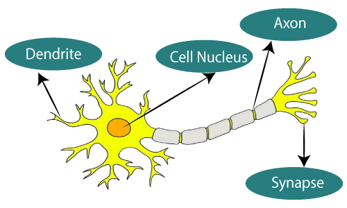

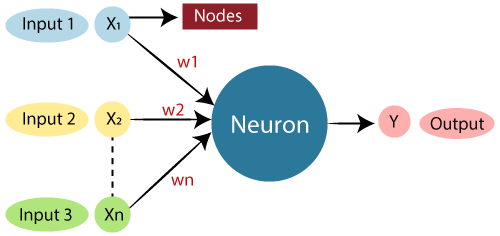

# How the Artifical Neuron connects to the Biological Neuron?

> An Artificial neuron is similar to biological neuron only in structure

> The process defined inside an Artifical neuron is totally different from the functions of a biological neuron

# Developments in ANN

1. **Perceptron** was introduced by Waren McCulloch and Walter pits in 1943
2. **LTU** was introduced by Frank Rosenblatt in 1957
3. Psychologists has introduced the concept of **connectinism** to improve ANN in 1980
4. MLP with sigmoid neuron was introduced in 1986 (Geoffrey Hinton)
5. Invention of **SVM** in 1990 sent ANN to a long break
6. Yann LeCun and Yoshua Bengio has introduced **CNN** in 1998
7. Glorot and others has improved MLP with new kernal initializers in 2010
8. Deep learning with modified activation functions was introduced in 2016 (Yoshua Bengio and others)
9. The **capsule network** was successfully implemented by Geoffrey Hinton in 2017
10. The trios– Hinton, Benjio & LeCune collectively announces new promises of Deep Learning to AI in 2021 July

# Artificial Neural Network

An Artificial Neural Network is a network of artificial neurons that attempts to mimic the network of neurons makes up a human brain so that computers will have an option to understand things and make decisions in a human-like manner.

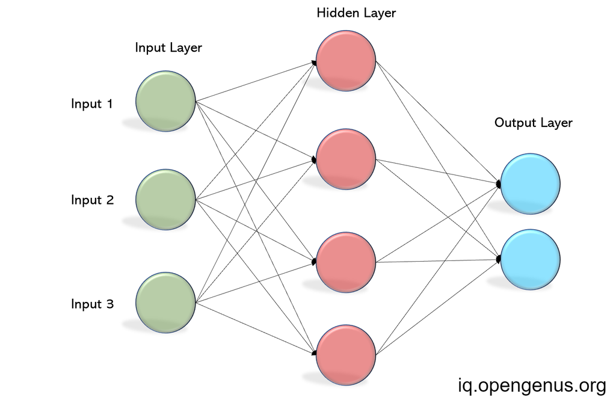

# The architecture of a neural networks

Basically, an ANN comprises of the following components:

1. An input layer that receives data and pass it on
2. A hidden layer
3. An output layer
4. Weights between the layers
5. A deliberate activation function for every hidden layer.

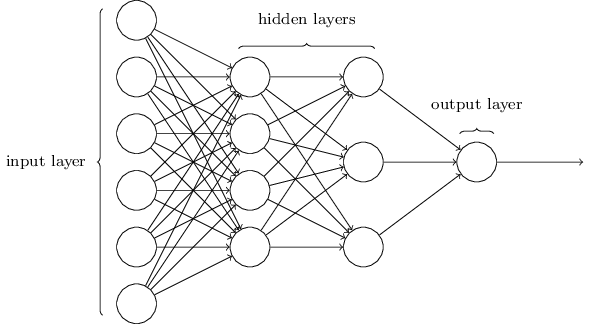

# Popular types of ANN

1. Feed forward network
2. Recurrent Neural Networks

# ANN with Mathematical notations

A typical ANN with above architecture can be reprecented as:

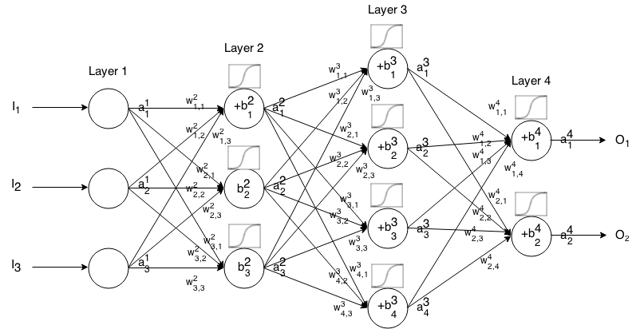

# Demystifyng learning in Neural Network

In this session we will discuss how the learning in neural network happens.

Learning in NNet happend in two phases

1. Forward pass (Forward propagation)
2. Back-propagation of errors and updating parameters

# Role of Activation Function in Learning

The activation function serves to introduce non-linearity in the modeling capabilities of the network.

# Popular Activation Functions in Deep Learning

1. Linear Activation
2. Sigmoid Activation
3. Tanh
4. Softmax
5. ReLU
6. Leaky Relu
7. Parametric ReLUs
8. ELUs

# Linear Activation Function

Mathematical Definition of Linear Activation Function is:
$$LA(x)=x$$

Generally used in input layers and regression problems.

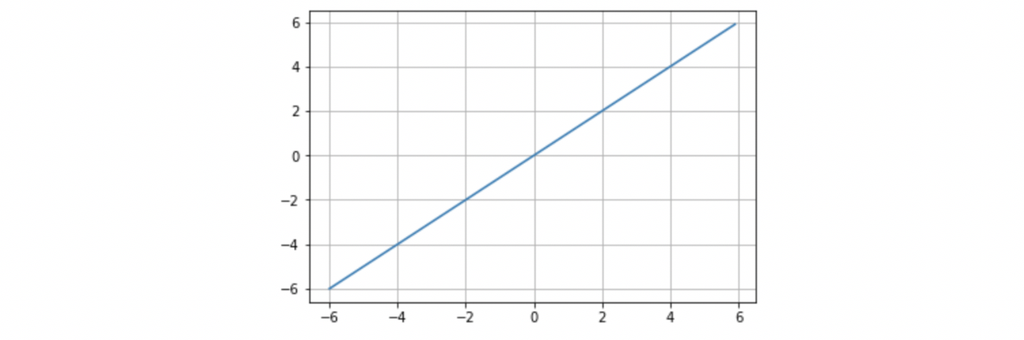

# Sigmoid Activation

Mathematical definition of sigmoid function is:
$$\sigma(h(x))=\dfrac{1}{1+e^{-h(x)}}$$

This activation is used in end hidden layers and output layer of binary classification models.

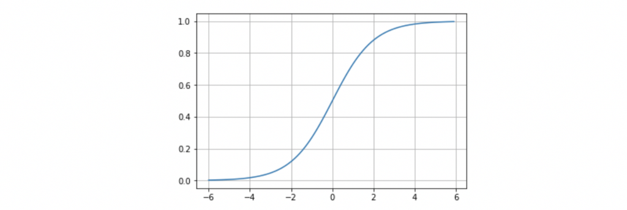

# Tanh

The mathematical definition of $\tanh$ activation function is defined by:

$$\tanh x=\dfrac{e^x-e^{-x}}{e^x+e^{-x}}$$

Generally this activation is used in output layer of binary classification models.

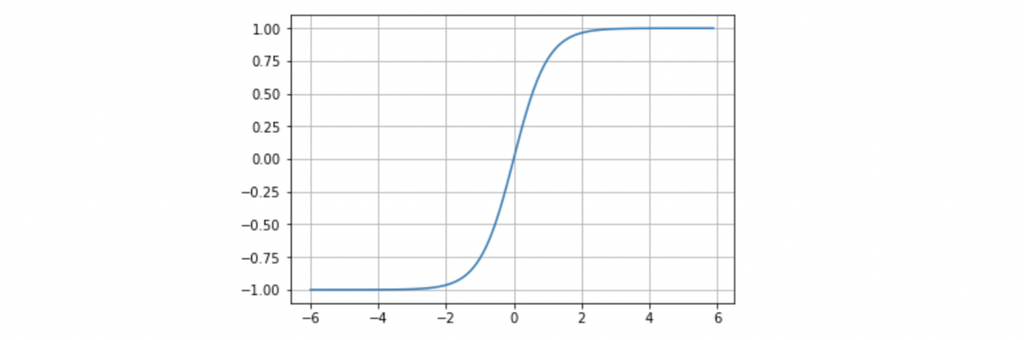

# Softmax

The mathematical definition of softmax activation function is :

$$S(z_i)=\dfrac{e^{z_i}}{\sum\limits_{i=1}^Ke^{z_i}}$$
Generally used in output layer of multi-class classification models.

The softmax function is differentiable everywhere. Softmax Activation function highlights the largest input and suppresses all the significantly smaller ones.

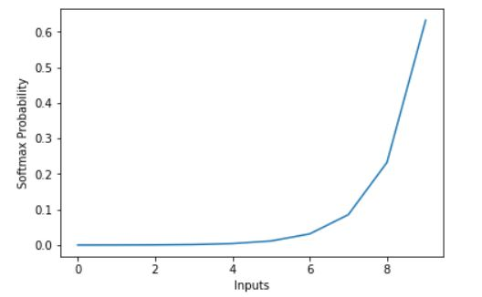

# ReLU

Mathematically the Relu function can be defined as $ReLu(x)=\max\{0,x\}$ or equivalently:

$$\text{ReLu(x)}=\left\{
\begin{array}{ll}
x&;x\geq 0\\
0&; x< 0
\end{array}
\right.$$

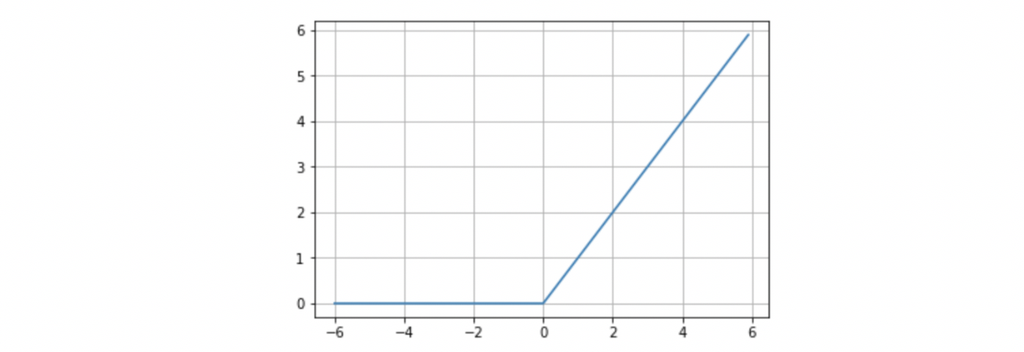

# Leaky Relu

It is defined as

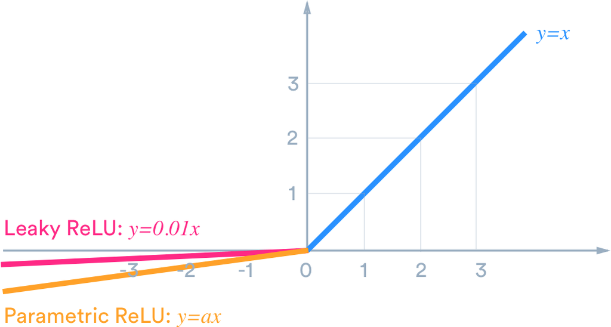

Still there are more useful activation like `Parametric ReLu` , `Exponential ReLu` etc.

$$\text{PReLu}(x)=\left\{
\begin{array}{ll}
x&;x\geq 0\\
ax&; x< 0
\end{array}
\right.\quad\quad \text{ELU}(x)=\left\{
\begin{array}{ll}
x&;x\geq 0\\
a(e^x-1)&; x< 0
\end{array}
\right.$$

# Comparison of Various Activation Functions

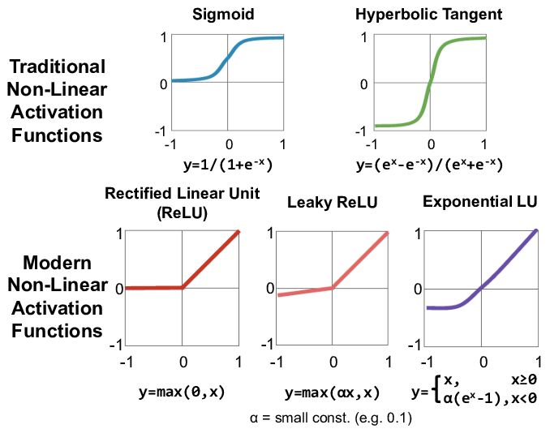

# Back-propogation to refine the learning process

The back-propagation is the procedure through which the ANN correct its mistakes in learning using output error. For this purpose the error in prediction will be calculated and is propogated backward relative to the contribution of each neuron in the network.

# Cost function in Neural Network

A cost function is a measure of “how good” a neural network did with respect to it’s given training sample and the expected output. It also may depend on variables such as weights and biases.

A cost function is a single value, not a vector, because it rates how good the neural network did as a whole.

Specifically, a cost function is of the form

$$J(W,B,S^r,E^r)$$

where $W$ is our neural network’s weights, $B$ is our neural network’s biases, $S^r$ is the input of a single training sample, and $E^r$ is the desired output of that training sample. Note this function can also potentially be dependent on $y^i_j$ and $z^i_j$ for any neuron $j$ in layer $i$, because those values are dependent on $W$, $B$, and $S^r$.

In backpropagation, the cost function is used to compute the relative error from our output layer, $\delta^L$, via

$$\delta^L_j = \frac{\partial J}{\partial w^L_j} \sigma^{ \prime}(z^i_j)$$

# Types of Cost functions

There are various types of cost functions in DNN. The most popular is the Mean Square error in the case of regression models.

A detailed description of various cost functions are given below. Note that these cost functions works well if the inputs are between 0 and 1.

1. Quadratics Cost

Also known as mean squared error, maximum likelihood, and sum squared error, this is defined as:

$$C_{MST}(W, B, S^r, E^r) = 0.5\sum\limits_j (a^L_j - E^r_j)^2$$

The gradient of this cost function with respect to the output of a neural network and some sample
$$\nabla_a C_{MST} = (a^L - E^r)$$

2. Cross-entropy cost

Also known as Bernoulli negative log-likelihood and Binary Cross-Entropy

$$C_{CE}(W, B, S^r, E^r) = -\sum\limits_j [E^r_j \text{ ln } a^L_j + (1 - E^r_j) \text{ ln }(1-a^L_j)]$$
The gradient of this cost function with respect to the output of a neural network and some sample r is:

$$\nabla_a C_{CE} = \frac{(a^L - E^r)}{(1-a^L)(a^L)}$$

3. Exponentional cost

This requires choosing some parameter $\tau$ that you think will give you the behavior you want. Typically you’ll just need to play with this until things work good.

$$C_{EXP}(W, B, S^r, E^r) = \tau\text{ }\exp(\frac{1}{\tau} \sum\limits_j (a^L_j - E^r_j)^2)$$

where $exp(x)$ is simply shorthand for $e^x$.

The gradient of this cost function with respect to the output of a neural network and some sample r is:

$$\nabla_a C = \frac{2}{\tau}(a^L- E^r)C_{EXP}(W, B, S^r, E^r)$$

4. Hellinger distance

$$C_{HD}(W, B, S^r, E^r) = \frac{1}{\sqrt{2}}\sum\limits_j(\sqrt{a^L_j}-\sqrt{E^r_j})^2$$

This needs to have positive values, and ideally values between 0 and 1. The same is true for the following divergences.

The gradient of this cost function with respect to the output of a neural network and some sample r is

$$\nabla_a C = \frac{\sqrt{a^L}-\sqrt{E^r}}{\sqrt{2}\sqrt{a^L}}$$

5. Kullback–Leibler divergence

Also known as Information Divergence, Information Gain, Relative entropy, KLIC, or KL Divergence Kullback–Leibler divergence is typically denoted

$$D_{\mathrm{KL}}(P\|Q) = \sum_i P(i) \, \ln\frac{P(i)}{Q(i)}$$

where $DKL(P∥Q)$ is a measure of the information lost when Q is used to approximate P. Thus we want to set $P=E^i$ and $Q=a^L$, because we want to measure how much information is lost when we use $a^i_j$ to approximate $E^i_j$. This gives us
$$C_{KL}(W, B, S^r, E^r)=\sum\limits_jE^r_j \log \frac{E^r_j}{a^L_j}$$

The other divergences here use this same idea of setting $P=E^i$ and $Q=a^L$.

The gradient of this cost function with respect to the output of a neural network and some sample r is

$$\nabla_a C = -\frac{E^r}{a^L}$$

6. Generalized Kullback–Leibler divergence

The GKLD is defined as

$$C_{GKL}(W, B, S^r, E^r)=\sum\limits_j E^r_j \log \frac{E^r_j}{a^L_j} -\sum\limits_j(E^r_j) + \sum\limits_j(a^L_j)$$

The gradient of this cost function with respect to the output of a neural network and some sample r is:

$$\nabla_a C = \frac{a^L-E^r}{a^L}$$

7. Itakura–Saito distance

$$C_{GKL}(W, B, S^r, E^r)= \sum_j \left(\frac {E^r_j}{a^L_j} - \log \frac{E^r_j}{a^L_j} - 1 \right)$$

The gradient of this cost function with respect to the output of a neural network and some sample r is:

$$\nabla_a C = \frac{a^L-E^r}{\left(a^L\right)^2}$$

# The Four pillers of Deep Learning

1. Linear Algebra
2. Probability Theory
3. Optimization
4. Statistics

# Move on to Democratizing ANN- Hands-On Session

https://tinyurl.com/t7pk9d7x